# InstaCart Predictive Analysis: Reorder_n

April Leclair, Daniel Ochoa, Hoang Anh Thai Vu, Qiuhan Sun

November 8, 2017

# Loading my Workspace

```r
# load("my_work_space.RData")
```

# Loading the Data

```r
load("../Source/orders_sample40.Rda")
load("../Source/order_products_sample40.Rda")
products <- read_csv("../Source/products.csv")
departments <- read_csv("../Source/departments.csv")
aisles <- read_csv("../Source/aisles.csv")
orders <- orders_sample40
order_products <- order_products_sample40
rm(orders_sample40, order_products_sample40)  # remove unnecessary data tables
```

```r
names(orders)
```

```
## [1] "order_id"               "user_id"
## [3] "eval_set"               "order_number"
## [5] "order_dow"              "order_hour_of_day"
## [7] "days_since_prior_order"
```

```r
names(order_products)
```

```
## [1] "order_id"          "product_id"        "add_to_cart_order"
## [4] "reordered"
```

```r
names(products)
```

```
## [1] "product_id"    "product_name"  "aisle_id"      "department_id"
```

```r
names(departments)
```

```
## [1] "department_id" "department"
```

```r
names(aisles)
```

```
## [1] "aisle_id" "aisle"
```

# Preparing the Data

Some variables are taken from Danny’s `PredictiveAnalysis_Products` file

## User with the highest order

### Prior

```r
top_order_userid_prior <-
  order_products %>%
  group_by(order_id) %>%
  summarise(num_products = n(),
            reorder_products = sum(reordered)) %>%
  left_join(orders, by="order_id") %>%
  filter(!is.na(days_since_prior_order),
         eval_set=="prior") %>%
  group_by(user_id) %>%
  summarize(num_products = sum(num_products),
            reorder_products = sum(reorder_products),
            ave_days_since = mean(days_since_prior_order),
            reord_ord_ratio = reorder_products/num_products) %>%
  arrange(desc(num_products))
head(top_order_userid_prior)
```

```
## # A tibble: 6 x 5
##   user_id num_products reorder_products ave_days_since reord_ord_ratio
##     <int>        <int>            <int>          <dbl>           <dbl>
## 1  108187         2729             2446       6.206897       0.8962990
## 2  181991         2412             2169       7.306122       0.8992537
## 3  100330         2321             2050       6.232143       0.8832400
## 4  175294         2260             1977       3.316327       0.8747788
## 5  106161         2161             1615       2.622449       0.7473392
## 6    2335         2150             1778       7.953488       0.8269767
```

### Train

```r
top_order_userid_train <-
  order_products %>%
  group_by(order_id) %>%
  summarise(num_products = n(),
            reorder_products = sum(reordered)) %>%
  left_join(orders, by="order_id") %>%
  filter(!is.na(days_since_prior_order),
         eval_set=="train") %>%
  group_by(user_id) %>%
  summarize(num_products = sum(num_products),
            reorder_products = sum(reorder_products),
            ave_days_since = mean(days_since_prior_order),
            reord_ord_ratio = reorder_products/num_products) %>%
  arrange(desc(num_products))
head(top_order_userid_train)
```

```
## # A tibble: 6 x 5
##   user_id num_products reorder_products ave_days_since reord_ord_ratio
##     <int>        <int>            <int>          <dbl>           <dbl>
## 1   83993           76               61             19       0.8026316
## 2  169647           75               63              8       0.8400000
## 3  181991           72               71              6       0.9861111
## 4   54566           65               45             16       0.6923077
## 5   43899           63               56             22       0.8888889
## 6  100330           62               61              9       0.9838710
```

```r
names(top_order_userid_train)
```

```
## [1] "user_id"          "num_products"     "reorder_products"
## [4] "ave_days_since"   "reord_ord_ratio"
```

# Predictions

## Q: Predict number of reorders per each user

## Regression Tree

I chose regression tree because tree is an easy and simple regression and classification method to use.

The tree below tells us that both `num_products` and `reord_order_ratio` are good candidates for predicting `reorder_products`. This makes sense since `num_products` is the denominator of `reord_order_ratio`. One indicator is that `ave_days_since` is not so predictive of `reorder_products` possibly because of missing variables.

I would like to do a filtered-by-a- `user_id` analysis after this file for further predictive analysis.

```
##
## Regression tree:
## tree(formula = reorder_products ~ num_products + ave_days_since +
##     reord_ord_ratio, data = top_order_userid_train)
## Variables actually used in tree construction:
## [1] "num_products"    "reord_ord_ratio"
## Number of terminal nodes:  11
## Residual mean deviance:  4.074 = 104000 / 25530
## Distribution of residuals:
##     Min.  1st Qu.   Median     Mean  3rd Qu.     Max.
## -12.7000  -1.1310  -0.1306   0.0000   0.8694  37.3000
```

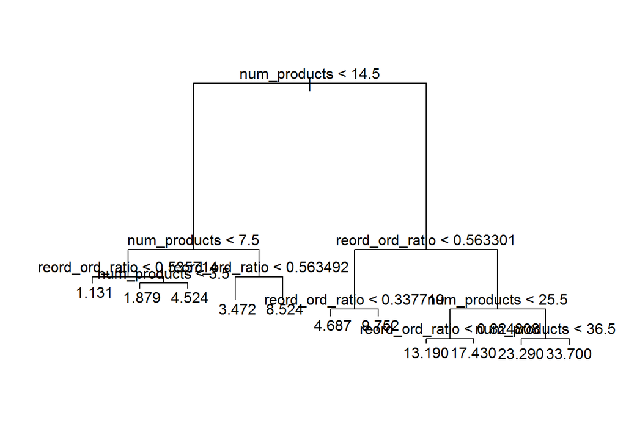

### Visualization: Orders and Reorders by Average Days Since Last Order

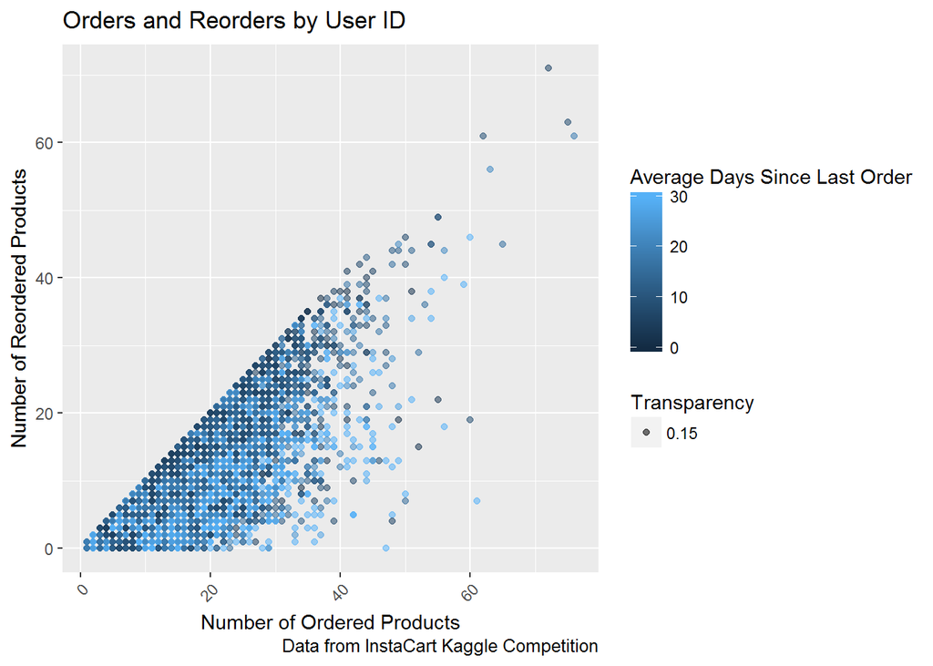

```r
top_order_userid_train %>%
  na.omit() %>%
  ggplot(aes(x=num_products, y=reorder_products, color=ave_days_since, alpha=0.15)) +
  geom_point() +
  theme(axis.text.x=element_text(angle=45,hjust=1)) +
  labs(x="Number of Ordered Products", y="Number of Reordered Products",
       title="Orders and Reorders by User ID",
       color="Average Days Since Last Order",
       alpha="Transparency",
       caption="Data from InstaCart Kaggle Competition")
```

It seems that the lower the `reord_ord_ratio`, the longer it takes for you to make an order again. However, this is not captured in the basic tree analysis.

## Gradient Boosted Tree

I chose gradient boosted tree because I have personally never used this method before, and wanted to explore the difference in outputs between other regression methods and GBT. Again, it seems that the variables in the data except for those that are directly related (`reord_ord_ratio` and `num_products`) do not really contribute to predicting `reorder_products`. As with the first analysis, `ave_days_since` does not explain the variability in `reorder_products` well.

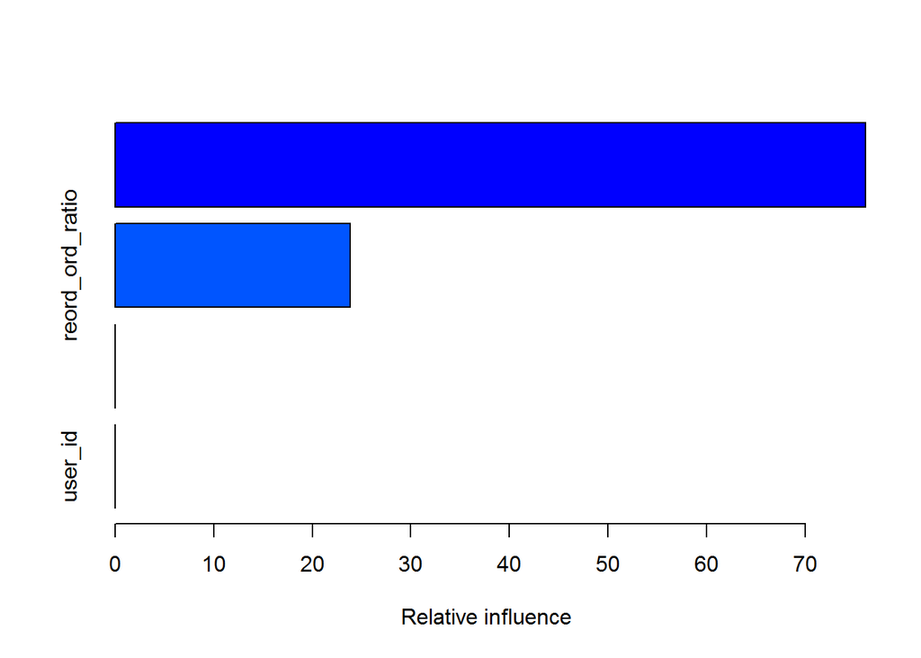

```
##                             var rel.inf
## num_products       num_products 76.1358
## reord_ord_ratio reord_ord_ratio 23.8642
## ave_days_since   ave_days_since  0.0000
## user_id                 user_id  0.0000
```

```r
set.seed(345)
grad_boost = gbm(reorder_products ~ num_products + ave_days_since + reord_ord_ratio + user_id,
                 data = top_order_userid_train,
              distribution = "gaussian", n.trees = 100,
              interaction.depth = 4)
summary(grad_boost) # Analyze variable importance
```

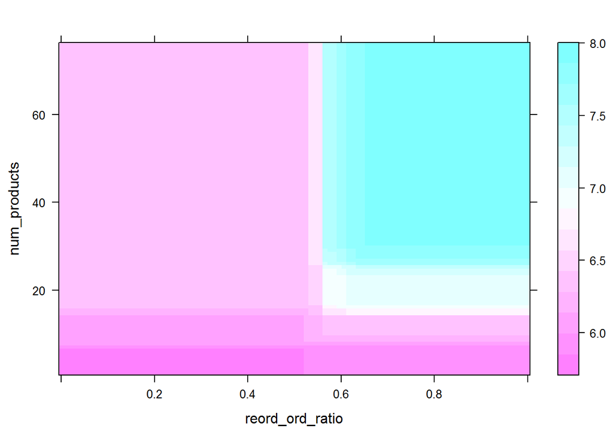

```r
plot(grad_boost, i = c("reord_ord_ratio","num_products"))
```

Again, I need to create more variables for better analysis. These files are in progress as of now.

```r
tree_test <- predict(reg_tree, top_order_userid_prior)
grad_boost_test <- predict(grad_boost, top_order_userid_prior, n.trees=100)

train_results <- top_order_userid_prior %>%
    mutate(tree_test, grad_boost_test)%>%
    mutate(tree_error=(reorder_products-tree_test),
           gb_error=(reorder_products-grad_boost_test))
mean(train_results$tree_error^2)
```

```
## [1] 27905.21
```

```r
mean(train_results$gb_error^2)
```

```
## [1] 31366.49
```

Tree has a lower mean squared.

```r
# save.image(file = "my_work_space.RData")
```